# STA257

Last edited: 2016-09-26 21:12

## random variables - recap

## the *functions* so far

1. Probabilitity measure: \(P:\mathcal{A} \longrightarrow \mathbb{R}\) and satisfies the three axioms. In general no "picture" possible, because its domain is a collection of events.
2. **Random variable** \(X:S\longrightarrow \mathbb{R}\). In general no "picture" possible, because its domain is a sample space. We care about: *its distribution*.
3. Cumulative distribution function \(F\) for the random variable \(X\). Defined as \(F(x) = P(X \le x)\). A picture is possible, and does give some information of limited use.

## recall "Example 1" "Example 2" and "Example 3"

Example 1: Toss a coin. \(S=\{H,T\}\). \(X=1\) if \(H\) appears and \(X=-1\) if \(T\) appears.

Example 2: Toss a coin repeatedly until \(H\) appears. \(S = \{H, TH, TTH,\ldots\}\). \(X_2\) is the number of tosses required.

Example 3: Pick a real number "uniformly" between 0 and 1. \(S=(0,1)\). \(X_3\) is the identity function. So:

\[F_{X_3}(x) = \begin{cases} 0 & x \le 0\\ x & 0 < x < 1\\ 1 & x \ge 1\end{cases}\]

## defining properties of a CDF

Theorem: For any r.v. \(X\), its cdf \(F(x)\) has the following properties:

\[\lim_{x \to -\infty} F(x) = 0,\]

\[\lim_{x \to \infty} F(x) = 1,\]

and \(F(x)\) is *right-continuous*, i.e. \[\lim_{x \to a+} F(x) = F(a).\]

The proof of this theorem uses The Continuity Theorem and its corollary. I'll do the middle property (see next *three* (new!) slides for an extra detail). The other two are left for you.

(advanced note: *any* function with these properties is a cdf for some \(X\). )

## notes — limits at infinity, and right-continuity (Part I)

There is the general definition of function limit, and function continuity. Here are some useful facts.

One can establish:

\[\lim_{x\to\infty} f(x) = L\]

by showing that \(\lim_{n\to\infty} f(x_n) = L\) for *any* sequence \(x_1 \le x_2 \le x_3 \le \cdots\) that goes to \(\infty\).

## notes — limits at infinity, and right-continuity (Part II)

One can also establish:

\[\lim_{x\to -\infty} f(x) = L\]

by showing that \(\lim_{n\to\infty} f(x_n) = L\) for *any* sequence \(x_1 \ge x_2 \ge x_3 \ge \cdots\) that goes to \(-\infty\).

## notes — limits at infinity, and right-continuity (Part III)

Finally, one can establish that a function is *right-continuous at* \(a\) by showing that

\[\lim_{n\to\infty} f(x_n) = f(a)\]

for *any* non-increasing sequence \(x_1 \ge x_2 \ge x_3 \ge \cdots\) that converges to \(a\).

## not done \(properly\) in class - the proof of the middle property (part I)

First, note that I *changed* what used to be the previous *one* slide into *three* slides with more explicitly useful information that is needed to prove all three of the cdf properties.

Theorem: If \(F\) is a cdf, \(\lim_{x\to\infty} F(x) = 1\).

Proof: First, see previous slides for a way to prove a "limit at infinity". (My first regret in class was not using this more specific result, and trying to be casual with the whole thing.)

Let \(x_1 \le x_2 \le x_3 \le \cdots\) be any unbounded non-decreasing sequence, so that it converges to \(+\infty\).

Define the *events* \(A_i = \{X \le x_i\}\) (my second regret was not carefully enough defining actual increasing sequence of events of interest.).

## not done \(properly\) in class - the proof of the middle property (part II)

Then \(A_i \subset A_{i+1}\) and \(\cup_{i=1}^\infty A_i\) is just the event \(\{X \in \mathbb{R}\}\), which we can call \(A\). (OK think informally that \(A = \{ -\infty < X < \infty \}\).

So by *The Continuity Theorem* we have \(\lim_{n\to\infty} P(A_n) = P(A)\). But \(P(A)=1\), since \(X\) has to take on *some* value. And \(P(A_n) = P(X \le x_n) = F(x_n)\) by construction of \(A_n\) and the definition of \(F\). So \(\lim_{n\to\infty}F(x_n) = 1\).

Since all this is true no matter what unbounded non-decreasing sequence we had started with we conclude:

\[\lim_{x\to\infty}F(x) = 1.\]

## discrete random variables

## a large class of random variables

*Discrete* random variables take on a finite or countably ("list-able") set of real outcomes.

e.g. the coin toss game, and tossing a coin until the first head appears.

A more convenient complete distribution descriptor is the collection of probabilities of the set of outcomes, called the *probability mass function* or pmf:

\[p(x) = P(X = x)\]

This function is non-zero on the values of \(X\), and formally 0 otherwise (usually just a formality).

## defining properties of a pmf

A function \(p(x)\) is a pmf if:

\[p(x) \ge 0\]

and

\[\sum_{\{x\,:\,p(x) > 0\}} p(x) = 1\]

## important concept: pmf and cdf are "equivalent"

Theorem: for any discrete random variable \(X\), the pmf and the cdf can be derived from each other.

Proof: Surprisingly fussy, so don't worry about it. The pmf to cdf direction is easy:

\[F(x) \sum_{y \le x} p(x)\]

The other direction isn't so easy. The idea (more important than the proof) is that you can recover the pmf from the cdf by noting that \(X\) takes on values exactly where the cdf jumps, and the sizes of those jumps are exactly the required probabilities.

## some important discrete random variables with special named distributions

## the Bernoulli(\(p\)) distributions - fundamental building blocks

If a random variable \(X\) takes on values 1 and 0 with probabilities \(p\) and \(1-p\) (for some fixed \(0 < p < 1\)), it is said to have a *Bernoulli distribution with parameter \(p\)*, or Bernoulli\((p)\).

The phrase "\(X\) has a Bernoulli distribution with parameter \(p\)" will be abbreviated as:

\[X \sim \text{Bernoulli}(p)\]

## "identically distributed"

It doesn't really matter what the underlying sample space \(S\) actually is:

1. toss a die; \(S = \{1,2,3,4,5,6\}\); define \(X_1(1)=X_1(2)=X_1(3)=0\) and \(X_1(4)=X_1(5)=X_1(6)=1\)
2. flip a coin; \(S = \{H, T\}\); define \(X_2(H) = 0\) and \(X_2(T) = 1\)

\(X_1\) and \(X_2\) have the *same distribution*, Bernoulli\(\left(\frac{1}{2}\right)\), but they are not the same *function*.

We say \(X_1\) and \(X_2\) are "identically distributed", and therefore the same as far as probability is concerned.

## Bernoulli(\(p\)) pmf and cdf

\[p(x) = \begin{cases} 1-p & : & x = 0,\\ p & : & x = 1\end{cases} \quad = \quad p^x(1-p)^{1-x} \text{ for } x \in \{0, 1\}\]

\[F(x) = P(X \le x) = \begin{cases} 0 & : & x < 0,\\ 1-p & : & 0 \le x < 1\\ 1 & : & x \ge 1\end{cases}\]

Often used as a model for an "experiment" or other random process that either produces an event \(A\) of interest, or it doesn't. If \(A\) is some event we can define the useful *indicator function*:

\[I_A = \begin{cases} 1 & \text{ when $A$ occurs}\\ 0 & \text{ otherwise}\end{cases}\]

\(I_A\) is a random variable. It will have a Bernouilli distribution with parameter \(p = P(A)\).

## thank you for subscribing to Bernoulli facts!

Sometimes we'll say \(q\) instead of \(1-p\).

It's not clear why the outcomes 0 and 1 are important and useful. Why not just focus on the underlying random outcome? More later.

It starts with the idea of *Bernoulli process*, which I'll introduce now but cannot completely describe until later.

## Bernoulli process

Consider an experiment with an event of interest \(A\). Sometimes (unfortunately!), when \(A\) occurs we call it a "success". Otherwise, it's a "failure".

Suppose we replicate the experiment. Maybe a finite number \(n\) times, or maybe indefinitely.

Each experiment repetition is independent of all the others. (What does this mean?)

If we let the result of the \(i^{th}\) replication be \(X_i = I_A\), then \(X_1, X_2, \ldots\) is called a Bernoulli process (or "sequence of Bernoulli trials").

## the Binomial distributions

Stop a Bernoulli(\(p\)) process after \(n\) trials. Count the number of "successes", or \(1\)'s.

This is a random variable. Call it \(X\).

What is the p.m.f. of \(X\)?

\[p(k) = P(X=k) = \begin{cases} {n \choose k} p^k(1-p)^{n-k} & x \in \{0,\ldots,n\}\\ 0 & \text{otherwise}\end{cases}\]

Is this a valid pmf? Yes. ("Binomial Theorem")

We say \(X\) has a Binomial\((n,p)\) distribution, or \(X \sim \text{Binomial}(n,p)\).

## a few examples…

The probability that someone is HIV+ given that their ELISA test comes back positive is \(0.2971\). Suppose we have 100 people with a positive ELISA test. How might one visualize the distribution of the number of people who are HIV+?

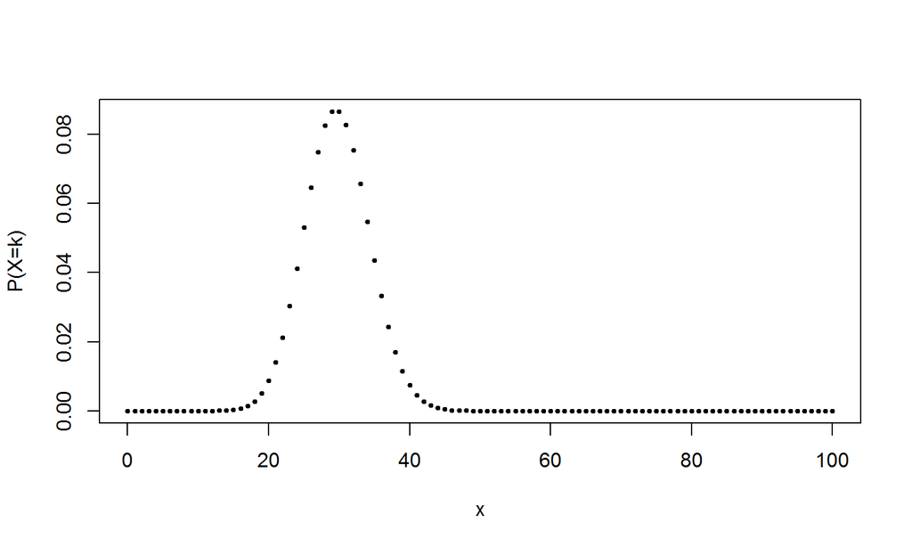

## …a few examples

The extreme cases have already been considered.

\[P(X=n)\] \[P(X=0)\] \[1-P(X=n)\] \[1-P(X=0)\]

## the geometric distributions

Consider a Bernoulli\((p)\) process. Count the number of trials until the first "success".

This is a random variable. Call it \(X\).

What is the p.m.f. of \(X\)?

\[p(k) = P(X=k) = \begin{cases} (1-p)^{k-1}p & x\in\{1,2,3,\ldots\}\\ 0 & \text{otherwise}\end{cases}\]

Is this a valid pmf? Yes.

We say \(X\) has a geometric distribution with paramter \(p\), or \(X \sim \text{Geometric}(p)\).

## the "negative binomial" distributions

Consider a Bernoulli\((p)\) process. Count the number of trials until the \(r^{th}\) "success".

This is a random variable. Call it \(X\).

What is the p.m.f. of \(X\)?

\[p(k) = P(X=k) = \begin{cases} {{k - 1} \choose {r - 1}}p^k(1-p)^{k-r} & x\in\{r,r+1,r+2,\ldots\}\\ 0 & \text{otherwise}\end{cases}\]

Is this a valid pmf? Yes (a little obscure to figure out)

We say \(X\) has a negative binomial distribution with paramters \(p\) and \(r\), or \(X \sim \text{NegBin}(p, r)\).